# 1. Research topic and background.

## a). Introduction.

### Overview of the topic.

The World Health Organization characterizes mental health disorders by a combination of abnormal thoughts, perception, emotions, behavior and relationships with others in the society. Mental health disorders include the following conditions, depression, bipolar disorder, schizophrenia and other psychoses dementia and developmental disorders including autism (World Health Organization (WHO), 2019). The prevalence of mental health disorders among individuals has affected many regardless of geographical location,employment status, religion or sex. These mental health disorders have affected individuals to the extent of some attempting suicide with a good number of them succeeding in commiting the act. Governments and non governmental organisations have initiated steps towards trying to curb the prevalence of mental health disorders in the general population, some of these steps include setting up rehabilitation centers to combat drug and substance abuse.

The application of modern technology such as artificial inteligence which is part of machine learning has also helped ease the effects of the mental health disorders in both the patients and health care providers. Despite mental health disorders being the 5th largest disease burden globally and it being in the top three disease burdens in most countries in the world (Datoni et al, 2021) its awareness is still low among the world population especially in low income countries.

### Relevant news or research articles.

Major depression being one of the most common mental illnesses in the world has led to some serious effects in individuals, the New York Times has concluded that, globally symptoms of anxiety and depression doubled during the pandemic. For example between the period of 2011-2015 in the united states emergency room visits related to depression, anxiety and similar conditions increased by 28 percent.

Suicide being the fourth leading cause of death among 14-19 year olds globally has an estimated 700,000 people attempting it yearly for every succesful suicide attempt there are many more attempting it this is according to the WHO, 2021. WHO has also noted that 77% of suicide deaths occur in low and middle income countries, the link between suicide and mental disorders has been established with other causes being personal crisis such as financial crisis and relationship breakups.

W.H.O has noted that due to new technologies that were unimaginable a decade ago, increasing pressure for cost efficiencies and higher productivity. The extent and pace of change can however when coupled with a working environment that take accounts of peoples mental weel being can lead to physical and mental disorders, harmful use of alcohol and other substance. The W.H.O estimates that depression and anxiety being two of the most common mental health disoders cost the global economy an estimated 1 trillion U.S dollars yearly.

### Motivation.

Individuals suffering from mental health disorders for long have been ignored and these has led to some unexpected occurrences, these include:

- (WHO, 2021) has suggested that more than 700,000 people die from suicide every year, it has also pointed out that for every suicide there are many more people who attempt suicide. Suicide is the fourth leading cause of death among 15- to 19-year-old individuals. This has been associated with mental health disorders, it has been established that individuals who suffer from depression and those that indulge in drug and substance abuse are more likely to attempt suicide which is the strongest risk factor.
- Labelling of individuals suffering from mental health disorders in Kenya as ‘mad people’ has led to most of them suffering from stigma. This has also increased the depression rates among them especially those individuals already suffering from diseases such as the HIV/AIDS. According to the centers for disease control and prevention (CDC), HIV stigma and discrimination affect the emotional well being and mental health of people living with HIV. American psychiatry association has pointed out that more than half of the people with mental health illnesses don’t receive help for their disorders this is because they delay seeking treatment due to concerns that they will be treated differently or the fear of losing their job and livelihood.

With the above factors stated and the fact that I have met individuals suffering from mental health disorders both friends and family who were in distress with the need for immediate medical assistance but no way of accessing it, I have decided to conduct this study to find a way of detecting individuals with mental health diseases at earlier stages.

### Objectives

The need to increase mental health awareness especially in the workplace and the general population is of great importance this is due to the fact that more than 10% of the world population experience mental health dioders while only 44% of the world population has some knowldge about mental health disorders. Increasing mental health awarenes is key to solving disoders related to mental health, hence we will be looking to incraese mental health awareness through our study.

The stigma associated with people identified from society especially in low income countries such as Kenya where some of the individuals experiencing these disoders might be branded as mad men since they lack the necessary mental health services to help them overcome these illnesses. Reducing stigma in individuals experiencing disorders through identification of variables that may lead to an individual experiencing mental health disorders will be key.

### Overview of key findings.

The research and statistics done on mental health awareness in the past have proven to be useful in trying to predict future trends regarding mental health in the global population. Some of these useful findings that i have found are;

- Mental health disoders are directly related to suicide cases globally, 60% of suicide cases are caused by individuals with a history of major depressive disoders (WHO, 2021). 77% occur in middle and low income countries disapproving the fact that suicide is done in high income countries. WHO has suggested that about 700,000 people commit suicide annualy with there being more suicide attempts for each succesful suicide case.
- Mental health disoders are more common in women than men, although men and women experience mental health and substance use disoders most illnesses classified under such as anxiety disoders, major depressive disoders and eating disoders are more common in women than men, but substance use dioders such as addiction are more common in men this is according to data available on institute of health metrics and evaluation (IHME).

## b) Research questions.

### Population and sampling method.

We will use simple random sampling in our study this will be through following the following steps so as to achieve it.

We will define our target population that is Kenyans between the ages of 18 to 50 years old this is so because this age group are the most affected by cases of mental health disorders and they make up 60% percent of the population (Aron O’Neill, 2021). From the target population stated above we will choose a simple random sample of n samples. This is number is dependent on our budget and the time that is allocated for the study.

Simple random sampling method was chosen because of its simplicity and prevents the researcher from displaying bias. Though its simple to conduct it is time consuming and we will be anticipating difficulty in accessing the full list of the population.

### Research questions.

Mental health awareness being the first step to be fulfilled in fighting mental health disorders will be key, so as to help individuals identify if they have mental health diseases, we will first need to educate them about mental health disorders in general. The first question to our research rises from here and we will need to answer it, What is the level of mental health awareness in Kenya?

Application of machine learning in also treating and predicting diseases also presents itself in other forms such as the detection of melanoma using deep learning models such as the convolutional neuro network (CNN) models (Nay chi Lyn et al, 2017). With proper data collection methods, the creation of models that can predict the occurrence of mental disorders in individuals also occurs if it is possible. Hence the question of how can unstructured supplementary service data (USSD) be applied in low-income countries like Kenya be used to ease data collection in low-income countries?

Depression is one of the most prevalent mental disorders, (saloni dattani et al, 2021) havefound out that globally about 792 million people have mental disorders this is about 1 in every ten people suffer from mental disorders, among these those suffering with major depressive disorders are 280 million. The question of how severe is depression in individuals between the age of 18 to 50 years in low-income countries arises?

It is undeniable to say that the effects of mental health disorders have been felt by everyone even in the workplace. Both employers and employees have suffered from the effects of mental health diseases, with some of the factors that contribute to both parties suffering is a toxic working environment. Hence the question of what steps have been taken in theworkplace to ensure that mental health is of importance?

## c) Domain concepts.

1. Mental health – mental health includes our emotional psychological and social well-being. It determines how we handle stress relate to others and make choices (mentalhealth, 2020)
2. Machine learning – is the study of computer algorithms that can improve automatically through experience and by use of data. Machine learning algorithms build a model based on sample data known as training data in order to make predictions or decisions without being explicitly programmed to do so (Wikipedia).
3. Mental health wellness – (Gina Marie Guarino, 2021) has suggested that mental health wellness is the awareness of one’s own ability to cope with stressors of day-to-day life while maintaining the ability to function effectively when socializing working learning and taking care of personal health and hygiene.
4. Mental health disorder – during the era of Diagnstic and statistical manual of mental disoders IV (DSM-IV) the definition of mental disorder was clinically significant behavioral or psychological or biological syndromes that are associated with present distress disability or significant impairment in the important areas of functioning.

# 2. Data sources.

### a) Survey methodology.

So as to colllect our survey data we followed teh following survey methodology:

- Selecting sample - Since our target population that was between teh age of 18 to 50 years old we selected a sample size for our study by From the target population stated above we will choose a simple random sample of n samples. This is number is dependent on our budget and the time that is allocated for the study. Simple random sampling method was used because of its simplicity that prevents the researcher from displaying bias. Though its simple to conduct it is time consuming and we will be anticipating difficulty in accessing the full list of the population.
- Research designs -The research design that was apllied was the Cross sectional study here a sample was chosen from the relevant population A cross-sectional study described characteristics of our population at one time, but could not give any insight as to the causes the population characteristics because it is a predictive, correlational design.
- Questionnaires - We then developed a questionnaire that was to filled out by respondents in our sample the questionanire included the following questions:

  ```
    - What age bracket do you fall into?
    - What is your gender?
    - Are you a Kenyan citizen?
    - Which county do you live in?
    - Do you live within a town area or outcasts?
    - What is the highest level of education you have completed?
    - What would describe your occupation?
    - How would you describe your income level?
    - How would you describe your social life?
    - Do you have any caring responsibilities?
    - How far is the nearest hospital facility from where you live?
    - How well are you vast with mental health issues?
    - Have you ever accessed any mental health services?
    - Are you aware of any mental health facility within a radius of 10km from your place of living?
    - If you are to access a mental health service / facility, what would be the main reason?
  ```

- Data collection - The data for our survey was collected using the JISC online survey and the link to the survey was sent to the our sample population.

### Data location.

The publicly obtained data was obtained from the Open Source Mental Illness (OSMI) an non governmental institution that is dedicated to fight the harmful stigma around mental health. The data can be found [here](https://www.kaggle.com/osmihelp/osmi-mental-health-in-tech-survey-2019), however the data we used here was for the whole years combined since the OSMI mental health in tech survey were introduced.

### Data collection methodology.

The method that was used to collect the data was by use of an online survey on their website the survey for this year (2022) is still running and open and anyone can participate in it the location of th survey is [here](https://osmi.typeform.com/to/rgU7eKxq). OSMI conducts survey mental health survey focusing in the tech industry yearly as from the year 2014.

### Ethical issues.

The ethical issues surrounding the collection and usage of mental health data is of great concern since health data is sensitive data the collection of the data especilly the structuring of teh questions has to be neatly done so as not to trigger the respondents emotions in any way. This was taken into consideration when collecting teh OSMI data by structuring teh most of teh questions to be open ended so to avoid teh questions looking like they were attacking the respondent. The identity of the respondents was also procted by labelling the respondents with unique ids that could not identify the respondents personally.

# 3. Data overview and pre-processing.

## Data types and pre-processing.

### Variable description.

```python
# importing the libraries that we will use
import pandas as pd
import numpy as np
import seaborn as sb
import matplotlib.pyplot as plt
```

```python
#importing the survey data and viewing the first ten rows
s_data = pd.read_excel('survey_data2.xlsx')
s_data.head(10)
```

|  | Age_bracket | Gender | Kenyan_citizen | County | Town | Level_of_education | Occupation | Income_level | Social_life | Responsibilities | Hospital | Mental_issues_know | Access_Facilities | Mental_Facilities_Km | Reason |
| --- | --- | --- | --- | --- | --- | --- | --- | --- | --- | --- | --- | --- | --- | --- | --- |
| 0 | 41-45 | Female | Yes | Nairobi | Town area | Bachelors Degree | Self-employed | For my age group, above average | Highly social | Primary carer of a child or children (under 18... | 0-5km | Have an idea | Yes | Yes | Recommend someone close to me to the service /... |
| 1 | 41-45 | Male | Yes | Nairobi | Town area | Masters Degree | Employed in an organization | For my age group, above average | I prefer my own company | Primary carer of a child or children (under 18... | 0-5km | Well knowledgeable | Yes | No | Learn my mental health status |
| 2 | 26-30 | Female | Yes | Nairobi | Town area | Bachelors Degree | Employed in an organization | For my age group, would consider below average | Partly social | Prefer not to disclose | 0-5km | Have an idea | No | Yes | Recommend someone close to me to the service /... |
| 3 | 26-30 | Female | Yes | Kajiado | Town area | Bachelors Degree | Self-employed | For my age group, would consider average | Partly social | Prefer not to disclose | 0-5km | Have an idea | No | No | Know more about the field |
| 4 | 26-30 | Male | Yes | Nairobi | Town area | Bachelors Degree | Employed in an organization | For my age group, would consider average | Partly social | None | 0-5km | Well knowledgeable | Yes | Yes | Learn my mental health status |
| 5 | 18-25 | Male | Yes | Nairobi | Town area | University Diploma | Student | For my age group, would consider below average | I prefer my own company | None | 0-5km | Have not had a chance to check on mental healt... | No | No | Not interested |
| 6 | 35-40 | Male | Yes | Kenya | Town area | Masters Degree | Employed in an organization | For my age group, above average | Partly social | Primary carer of a child or children (under 18... | 0-5km | Well knowledgeable | Yes | No | Learn my mental health status |
| 7 | 26-30 | Male | Yes | Nairobi | Town area | Bachelors Degree | Employed in an organization | For my age group, would consider average | Highly social | None | 0-5km | Have an idea | No | Yes | Learn my mental health status |
| 8 | 26-30 | Female | Yes | Kajiado | Town area | Bachelors Degree | Employed in an organization | For my age group, would consider average | Partly social | Primary carer of a child or children (under 18... | 0-5km | Have not had a chance to check on mental healt... | No | No | Recommend someone close to me to the service /... |
| 9 | 26-30 | Female | Yes | Nairobi | Town area | Bachelors Degree | Self-employed | For my age group, would consider average | Partly social | Prefer not to disclose | 0-5km | Have an idea | No | No | Know more about the field |

```python
#importing our public data
#viewing the first ten rows of our public data.
p_data = pd.read_csv("health data.csv")
p_data.head(10)
```

|  | ResponseID | Are you selfemployed | How many employees does your company or organization have | Is your employer primarily a tech companyorganization | Is your primary role within your company related to techIT | Do you have previous employers | Do you have a family history of mental illness | Have you had a mental health disorder in the past | Do you currently have a mental health disorder | If yes, what conditions have you been diagnosed with | ... | What country do you live in | What US state or territory do you live in | What country do you work in | What US state or territory do you work in | Which of the following best describes your work position | Do you work remotely | Question Group | Question about speaking openly about mental health vs physical health | Question | Response |
| --- | --- | --- | --- | --- | --- | --- | --- | --- | --- | --- | --- | --- | --- | --- | --- | --- | --- | --- | --- | --- | --- |
| 0 | r00000 | False | 26-100 | True | NaN | True | No | Yes | No | NaN | ... | United Kingdom | NaN | United Kingdom | NaN | Back-end Developer | Sometimes | Resources for employees with mental health dis... | No | Does your employer provide mental health benef... | Not eligible for coverage / N/A |
| 1 | r00000 | False | 26-100 | True | NaN | True | No | Yes | No | NaN | ... | United Kingdom | NaN | United Kingdom | NaN | Back-end Developer | Sometimes | Resources for employees with mental health dis... | No | Do you know the options for mental health care... | NaN |
| 2 | r00000 | False | 26-100 | True | NaN | True | No | Yes | No | NaN | ... | United Kingdom | NaN | United Kingdom | NaN | Back-end Developer | Sometimes | Safe and supportive workplce for those with me... | No | Has your employer ever formally discussed ment... | No |
| 3 | r00000 | False | 26-100 | True | NaN | True | No | Yes | No | NaN | ... | United Kingdom | NaN | United Kingdom | NaN | Back-end Developer | Sometimes | Resources for employees with mental health dis... | No | Does your employer offer resources to learn mo... | No |
| 4 | r00000 | False | 26-100 | True | NaN | True | No | Yes | No | NaN | ... | United Kingdom | NaN | United Kingdom | NaN | Back-end Developer | Sometimes | Resources for employees with mental health dis... | No | Is your anonymity protected if you choose to t... | I don't know |
| 5 | r00000 | False | 26-100 | True | NaN | True | No | Yes | No | NaN | ... | United Kingdom | NaN | United Kingdom | NaN | Back-end Developer | Sometimes | Impact of mental disorders on worker productivity | No | If a mental health issue prompted you to reque... | Very easy |
| 6 | r00000 | False | 26-100 | True | NaN | True | No | Yes | No | NaN | ... | United Kingdom | NaN | United Kingdom | NaN | Back-end Developer | Sometimes | Speaking openly about a mental health disorder... | Yes | Do you think that discussing a mental health d... | No |
| 7 | r00000 | False | 26-100 | True | NaN | True | No | Yes | No | NaN | ... | United Kingdom | NaN | United Kingdom | NaN | Back-end Developer | Sometimes | NaN | Yes | Do you think that discussing a physical health... | No |
| 8 | r00000 | False | 26-100 | True | NaN | True | No | Yes | No | NaN | ... | United Kingdom | NaN | United Kingdom | NaN | Back-end Developer | Sometimes | Speaking openly about a mental health disorder | No | Would you feel comfortable discussing a mental... | Maybe |
| 9 | r00000 | False | 26-100 | True | NaN | True | No | Yes | No | NaN | ... | United Kingdom | NaN | United Kingdom | NaN | Back-end Developer | Sometimes | Speaking openly about a mental health disorder... | No | Would you feel comfortable discussing a mental... | Yes |

10 rows × 27 columns

```python
s_data.columns
```

```
Index(['Age_bracket', 'Gender', 'Kenyan_citizen', 'County', 'Town',
       'Level_of_education', 'Occupation', 'Income_level', 'Social_life',
       'Responsibilities', 'Hospital', 'Mental_issues_know',
       'Access_Facilities', 'Mental_Facilities_Km', 'Reason'],
      dtype='object')
```

Age - What age bracket do you fall into? • 18-25 • 26-30 • 35-40 • 41-45 • 46-50 • 50+

Gender - What is your gender? • Female • Male

Kenyan_citizen - Are you a Kenyan citizen? • Yes • No County - Which county do you live in? (Open Text box provided)

Town - Do you live within a town area or outcasts? • Town area • Outcasts (5km+ from main town)

Level_of_education - What is the highest level of education you have completed? • Primary school • Secondary school (e.g., KCSE, GCSE or level 2 qualifications) • Secondary school or college (e.g., IB, A-Levels, advanced apprenticeship, NVQ, BTEC) • University Certificate • University Diploma • Bachelor’s Degree • Master’s Degree • Doctoral degree

Occupation - What would describe your occupation? • Self-employed • Small Medium Enterprise • Start-up • Student • Internship • Employed in an organization • Retired

Social_life - How would you describe your social life? • Highly social • Partly social • I prefer my own company

Responsibilities - Do you have any caring responsibilities? • None • Primary carer of a child or children (under 18 years) • Primary carer of a disabled child or children (under 18 years) • Primary carer or assistant for a disabled adult (18 years and over) • Primary carer or assistant for an older person or people (65 years and over) • Secondary carer (another person carries out the main caring role) • Prefer not to disclose

Hospital - How far is the nearest hospital facility from where you live? • 0-5km • 6-10km • 11km+

Mental_issues_know - How well are you vast with mental health issues? • Well knowledgeable • Have an idea • Have not had a chance to check on mental health issues

Access_facilities - Have you ever accessed any mental health services? • Yes • No

Mental_Facilities_Km - Are you aware of any mental health facility within a radius of 10km from your place of living? • Yes • No

Reason - If you are to access a mental health service / facility, what would be the main reason? • Learn my mental health status • Seek help • Know more about the field • Recommend someone close to me to the service / facility • Not interested

For the public data.

```python
p_data.columns
```

```
Index(['ResponseID', 'Are you selfemployed',
       'How many employees does your company or organization have',
       'Is your employer primarily a tech companyorganization',
       'Is your primary role within your company related to techIT',
       'Do you have previous employers',
       'Do you have a family history of mental illness',
       'Have you had a mental health disorder in the past',
       'Do you currently have a mental health disorder',
       'If yes, what conditions have you been diagnosed with',
       'If maybe, what conditions do you believe you have',
       'Have you been diagnosed with a mental health condition by a medical professional',
       'If so, what conditions were you diagnosed with',
       'Have you ever sought treatment for a mental health issue from a mental health professional',
       'What is your age', 'What is your gender ', 'Age Group',
       'What country do you live in',
       'What US state or territory do you live in',
       'What country do you work in',
       'What US state or territory do you work in',
       'Which of the following best describes your work position',
       'Do you work remotely', 'Question Group',
       'Question about speaking openly about mental health vs physical health',
       'Question', 'Response'],
      dtype='object')
```

- ResponseID
- Are you selfemployed?
- How many employees does your company or organization have?
- Is your employer primarily a tech companyorganization?
- Is your primary role within your company related to techIT?
- Is your primary role within your company related to techIT?
- Do you have previous employers?
- Do you have a family history of mental illness?
- Have you had a mental health disorder in the past?
- Do you currently have a mental health disorder?
- If yes, what conditions have you been diagnosed with?
- If maybe, what conditions do you believe you have?
- Have you been diagnosed with a mental health condition by a medical professional?
- If so, what conditions were you diagnosed with?
- Have you ever sought treatment for a mental health issue from a mental health professional?
- What is your age', 'What is your gender ?
- Age Group?
- What country do you live in?
- What US state or territory do you live in?
- What country do you work in?
- What US state or territory do you work in?
- of the following best describes your work position?
- Do you work remotely', 'Question Group?
- Question about speaking openly about mental health vs physical health?
- Question ? Response

### Data types.

```python
#checking the shape of both datasets
x = s_data.shape
print ('The shape of the survey data is :' + str(x))
y = p_data.shape
print ('The shape of the public data is:' + str(y))
```

```
The shape of the survey data is :(38, 15)
The shape of the public data is:(60186, 27)
```

```python
# Getting the general information and the datatypes of the survey data.
p_data.info()
```

```
<class 'pandas.core.frame.DataFrame'>
RangeIndex: 60186 entries, 0 to 60185
Data columns (total 27 columns):
 #   Column                                                                                      Non-Null Count  Dtype
---  ------                                                                                      --------------  -----
 0   ResponseID                                                                                  60186 non-null  object
 1   Are you selfemployed                                                                        60186 non-null  bool
 2   How many employees does your company or organization have                                   48132 non-null  object
 3   Is your employer primarily a tech companyorganization                                       48132 non-null  object
 4   Is your primary role within your company related to techIT                                  11046 non-null  object
 5   Do you have previous employers                                                              60186 non-null  bool
 6   Do you have a family history of mental illness                                              60186 non-null  object
 7   Have you had a mental health disorder in the past                                           60186 non-null  object
 8   Do you currently have a mental health disorder                                              60186 non-null  object
 9   If yes, what conditions have you been diagnosed with                                        23856 non-null  object
```

[output cut: 19 more lines]

```python
#Gettting the general information and data types of survey data.
s_data.info()
```

```
<class 'pandas.core.frame.DataFrame'>
RangeIndex: 38 entries, 0 to 37
Data columns (total 15 columns):
 #   Column                Non-Null Count  Dtype
---  ------                --------------  -----
 0   Age_bracket           38 non-null     object
 1   Gender                38 non-null     object
 2   Kenyan_citizen        38 non-null     object
 3   County                38 non-null     object
 4   Town                  38 non-null     object
 5   Level_of_education    38 non-null     object
 6   Occupation            38 non-null     object
 7   Income_level          38 non-null     object
 8   Social_life           38 non-null     object
 9   Responsibilities      38 non-null     object
 10  Hospital              38 non-null     object
 11  Mental_issues_know    38 non-null     object
 12  Access_Facilities     38 non-null     object
 13  Mental_Facilities_Km  38 non-null     object
 14  Reason                38 non-null     object
dtypes: object(15)
memory usage: 4.6+ KB
```

### Data cleaning and pre-processing.

```python
#dropping the column of response id.
p_data1 = p_data.drop(['ResponseID'], axis = 1)
p_data1.head()
```

|  | Are you selfemployed | How many employees does your company or organization have | Is your employer primarily a tech companyorganization | Is your primary role within your company related to techIT | Do you have previous employers | Do you have a family history of mental illness | Have you had a mental health disorder in the past | Do you currently have a mental health disorder | If yes, what conditions have you been diagnosed with | If maybe, what conditions do you believe you have | ... | What country do you live in | What US state or territory do you live in | What country do you work in | What US state or territory do you work in | Which of the following best describes your work position | Do you work remotely | Question Group | Question about speaking openly about mental health vs physical health | Question | Response |
| --- | --- | --- | --- | --- | --- | --- | --- | --- | --- | --- | --- | --- | --- | --- | --- | --- | --- | --- | --- | --- | --- |
| 0 | False | 26-100 | True | NaN | True | No | Yes | No | NaN | NaN | ... | United Kingdom | NaN | United Kingdom | NaN | Back-end Developer | Sometimes | Resources for employees with mental health dis... | No | Does your employer provide mental health benef... | Not eligible for coverage / N/A |
| 1 | False | 26-100 | True | NaN | True | No | Yes | No | NaN | NaN | ... | United Kingdom | NaN | United Kingdom | NaN | Back-end Developer | Sometimes | Resources for employees with mental health dis... | No | Do you know the options for mental health care... | NaN |
| 2 | False | 26-100 | True | NaN | True | No | Yes | No | NaN | NaN | ... | United Kingdom | NaN | United Kingdom | NaN | Back-end Developer | Sometimes | Safe and supportive workplce for those with me... | No | Has your employer ever formally discussed ment... | No |
| 3 | False | 26-100 | True | NaN | True | No | Yes | No | NaN | NaN | ... | United Kingdom | NaN | United Kingdom | NaN | Back-end Developer | Sometimes | Resources for employees with mental health dis... | No | Does your employer offer resources to learn mo... | No |
| 4 | False | 26-100 | True | NaN | True | No | Yes | No | NaN | NaN | ... | United Kingdom | NaN | United Kingdom | NaN | Back-end Developer | Sometimes | Resources for employees with mental health dis... | No | Is your anonymity protected if you choose to t... | I don't know |

5 rows × 26 columns

```python
#renaming the survey columns to shorter names that we can work with easily.
p_data1.columns = ['employment','no_employees',"type_employer",'role','previous_employer','family_history','history_mhd','current_mhd','mhd_condition','mhd_condition2','prof_diagnosis','mhd_condition3',"treatment",'age','gender','age_group','country','us_state','work_country','work_state',"work_position",'work_remotely','question_group','mental_pysical','question','response']
p_data1.columns
```

```
Index(['employment', 'no_employees', 'type_employer', 'role',
       'previous_employer', 'family_history', 'history_mhd', 'current_mhd',
       'mhd_condition', 'mhd_condition2', 'prof_diagnosis', 'mhd_condition3',
       'treatment', 'age', 'gender', 'age_group', 'country', 'us_state',
       'work_country', 'work_state', 'work_position', 'work_remotely',
       'question_group', 'mental_pysical', 'question', 'response'],
      dtype='object')
```

Checking the sum of missing vcalues for the survey and public data.

```python
#public data
p_data1.isnull().sum().sort_values(ascending = False)
```

```
role                 49140
mhd_condition2       46662
mhd_condition        36330
mhd_condition3       30324
us_state             24906
work_state           24444
response             16340
type_employer        12054
no_employees         12054
question_group        8598
age                     84
prof_diagnosis           0
treatment                0
current_mhd              0
gender                   0
age_group                0
country                  0
history_mhd              0
work_country             0
family_history           0
work_position            0
work_remotely            0
previous_employer        0
mental_pysical           0
question                 0
employment               0
dtype: int64
```

```python
#survey data
s_data.isnull().sum().sort_values(ascending = False)
```

```
Age_bracket             0
Gender                  0
Kenyan_citizen          0
County                  0
Town                    0
Level_of_education      0
Occupation              0
Income_level            0
Social_life             0
Responsibilities        0
Hospital                0
Mental_issues_know      0
Access_Facilities       0
Mental_Facilities_Km    0
Reason                  0
dtype: int64
```

### Missing values.

Since we only have missing values in the publicy obtained data we will be evaluating this dataset only.

```python
#importing the missingno module to visualize and interpret relationships between missing values.
import missingno as msno
```

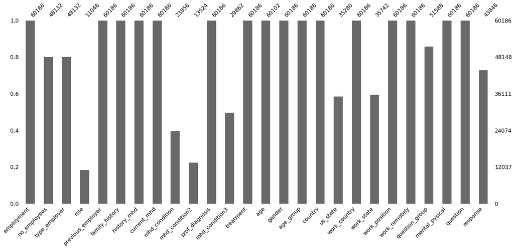

```python
#Checking the missing values in the publicly obtained data
msno.bar(p_data1)
```

The bar plot above visualizes the amount of missing values in the publicly obtained data, missing values vary from one column to the other as seen above the column of Role has the most missing values with only less than 12000 non-null values.

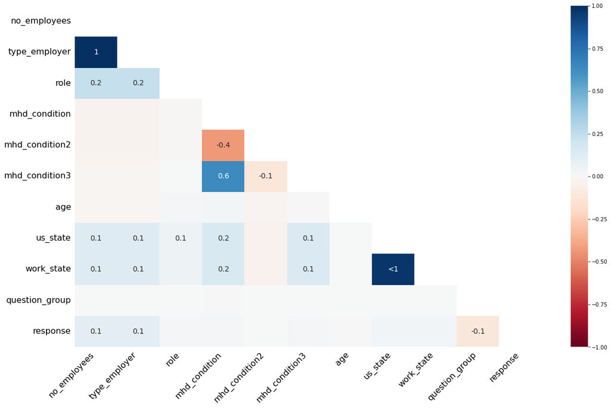

```python
#checking the relationship between missing values
msno.heatmap(p_data1)
```

The heatmap above plots how missing values in a column above affects the occurence of missing values in other columns, this in turn gives us correlations between the value of -1 and 1 this corelation can be interpreted as follows:

- A value near 1 means that when one column has missing values then the other column is likely to have missing values.
- A value of 0 means that the columns are independet of one another regarding the occurrence of missing values.
- A value near -1 means that when one column has missing values then the other column has non null values The conditions above can be used to interpret our the relationship between our columns to decide what will will do with columns with missing values.

Since we will be checking mental disorders in countries only, it will be wise to drop the column of states in the US. The question and response columns are also to be dropped since they contain feedback that is unique from one respondent to another.

```python
#dropping unnecessary columns.
p_data2 = p_data1.drop(columns = ['response', 'question', 'us_state', 'work_state'])
p_data2.columns
```

```
Index(['employment', 'no_employees', 'type_employer', 'role',
       'previous_employer', 'family_history', 'history_mhd', 'current_mhd',
       'mhd_condition', 'mhd_condition2', 'prof_diagnosis', 'mhd_condition3',
       'treatment', 'age', 'gender', 'age_group', 'country', 'work_country',
       'work_position', 'work_remotely', 'question_group', 'mental_pysical'],
      dtype='object')
```

```python
#dealing with missing values column by column that have missing values.
p_data2.isnull().sum().sort_values(ascending = False)
```

```
role                 49140
mhd_condition2       46662
mhd_condition        36330
mhd_condition3       30324
type_employer        12054
no_employees         12054
question_group        8598
age                     84
gender                   0
work_remotely            0
work_position            0
work_country             0
country                  0
age_group                0
employment               0
treatment                0
prof_diagnosis           0
current_mhd              0
history_mhd              0
family_history           0
previous_employer        0
mental_pysical           0
dtype: int64
```

Since the column of role has over 80% missing values we will drop it and its relationship with other columns is less either 0 or 0.1 or 0.2 we will drop it.

```python
#dropping the column of role
p_data3 = p_data2.drop(columns = ['role'])
p_data3.head()
```

|  | employment | no_employees | type_employer | previous_employer | family_history | history_mhd | current_mhd | mhd_condition | mhd_condition2 | prof_diagnosis | ... | treatment | age | gender | age_group | country | work_country | work_position | work_remotely | question_group | mental_pysical |
| --- | --- | --- | --- | --- | --- | --- | --- | --- | --- | --- | --- | --- | --- | --- | --- | --- | --- | --- | --- | --- | --- |
| 0 | False | 26-100 | True | True | No | Yes | No | NaN | NaN | True | ... | False | 39.0 | Male | 36-40 | United Kingdom | United Kingdom | Back-end Developer | Sometimes | Resources for employees with mental health dis... | No |
| 1 | False | 26-100 | True | True | No | Yes | No | NaN | NaN | True | ... | False | 39.0 | Male | 36-40 | United Kingdom | United Kingdom | Back-end Developer | Sometimes | Resources for employees with mental health dis... | No |
| 2 | False | 26-100 | True | True | No | Yes | No | NaN | NaN | True | ... | False | 39.0 | Male | 36-40 | United Kingdom | United Kingdom | Back-end Developer | Sometimes | Safe and supportive workplce for those with me... | No |
| 3 | False | 26-100 | True | True | No | Yes | No | NaN | NaN | True | ... | False | 39.0 | Male | 36-40 | United Kingdom | United Kingdom | Back-end Developer | Sometimes | Resources for employees with mental health dis... | No |
| 4 | False | 26-100 | True | True | No | Yes | No | NaN | NaN | True | ... | False | 39.0 | Male | 36-40 | United Kingdom | United Kingdom | Back-end Developer | Sometimes | Resources for employees with mental health dis... | No |

5 rows × 21 columns

```python
#dealing with missing values in the columns stated above, column by column.
#filling the missing values with the word None.
p_data4 = p_data3['mhd_condition'].fillna('None')
p_data5 = p_data3['mhd_condition2'].fillna('None')
p_data6 = p_data3['mhd_condition3'].fillna('None')
#replacing the column in the previous dataframe with the new column above.
p_data3['mhd_condition'] = p_data4
p_data3['mhd_condition2'] = p_data5
p_data3['mhd_condition3'] = p_data6
p_data3.head()
```

|  | employment | no_employees | type_employer | previous_employer | family_history | history_mhd | current_mhd | mhd_condition | mhd_condition2 | prof_diagnosis | ... | treatment | age | gender | age_group | country | work_country | work_position | work_remotely | question_group | mental_pysical |
| --- | --- | --- | --- | --- | --- | --- | --- | --- | --- | --- | --- | --- | --- | --- | --- | --- | --- | --- | --- | --- | --- |
| 0 | False | 26-100 | True | True | No | Yes | No | None | None | True | ... | False | 39.0 | Male | 36-40 | United Kingdom | United Kingdom | Back-end Developer | Sometimes | Resources for employees with mental health dis... | No |
| 1 | False | 26-100 | True | True | No | Yes | No | None | None | True | ... | False | 39.0 | Male | 36-40 | United Kingdom | United Kingdom | Back-end Developer | Sometimes | Resources for employees with mental health dis... | No |
| 2 | False | 26-100 | True | True | No | Yes | No | None | None | True | ... | False | 39.0 | Male | 36-40 | United Kingdom | United Kingdom | Back-end Developer | Sometimes | Safe and supportive workplce for those with me... | No |
| 3 | False | 26-100 | True | True | No | Yes | No | None | None | True | ... | False | 39.0 | Male | 36-40 | United Kingdom | United Kingdom | Back-end Developer | Sometimes | Resources for employees with mental health dis... | No |
| 4 | False | 26-100 | True | True | No | Yes | No | None | None | True | ... | False | 39.0 | Male | 36-40 | United Kingdom | United Kingdom | Back-end Developer | Sometimes | Resources for employees with mental health dis... | No |

5 rows × 21 columns

```python
p_data3.isnull().sum().sort_values(ascending = False)
```

```
type_employer        12054
no_employees         12054
question_group        8598
age                     84
employment               0
work_remotely            0
work_position            0
work_country             0
country                  0
age_group                0
gender                   0
mhd_condition3           0
treatment                0
prof_diagnosis           0
mhd_condition2           0
mhd_condition            0
current_mhd              0
history_mhd              0
family_history           0
previous_employer        0
mental_pysical           0
dtype: int64
```

The column of age being an important column and having less than 100 missing values we will replace the missing values using the mean of the non null values.

```python
#dealing with the column age
#checking the column type
p_data3.age.dtype

#checking the statistics of the column
xv = p_data3.age.mean()
xv
p_data11 = p_data3.age.fillna(xv)
p_data3['age'] = p_data11
```

The remaining columns contain strings as their elements, this leaves us with the option of filling them with values directly below or those above them.

```python
#dealing with missing values in the remaining columns
p_data4 = p_data3.fillna(method = 'pad')
p_data5 = p_data4.fillna(method = 'bfill')
p_data5.isnull().sum()
```

```
employment           0
no_employees         0
type_employer        0
previous_employer    0
family_history       0
history_mhd          0
current_mhd          0
mhd_condition        0
mhd_condition2       0
prof_diagnosis       0
mhd_condition3       0
treatment            0
age                  0
gender               0
age_group            0
country              0
work_country         0
work_position        0
work_remotely        0
question_group       0
mental_pysical       0
dtype: int64
```

### Outliers.

To check for outliers in our data we will need the variables to have the correct data types i.e integer or float in the two datasets after setting them in order we will be checking the column age for the public data for outliers.

```python
#checking for the maximum and minimum value in the age column
dy = p_data5.age.max()
dh = p_data5.age.min()
print ('The maximum value is : ' + str(dy), "The minimum value is : " + str(dh))
```

```
The maximum value is : 99.0 The minimum value is : 15.0
```

```
array([[<AxesSubplot:title={'center':'age'}>]], dtype=object)
```

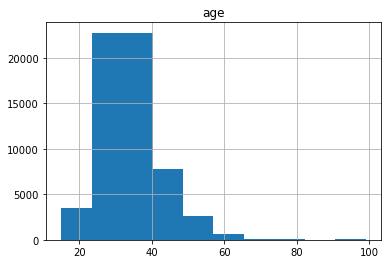

```python
# Creating a histogram to visualize the outliers.
p_data5.hist(bins = 10)
```

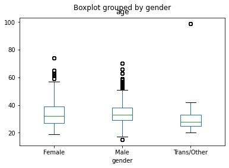

```python
#visualizing the outliers in our column age using boxplots and sorting the boxplots by gender.
p_data5.boxplot(column = ['age'], by = 'gender', grid = False)
```

Having seen that there are outliers in our column age we will take the necessary steps to treat the outliers in our column. We will replace the outliers in column with their median value of the variable we will not use the mean value since it is affected by the outliers.

### Treating outliers.

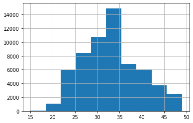

```python
#we will first find the 50th percentile of the variable.
j50 = p_data5.age.quantile(0.50)
#finding the 95th percentile of the data.
j95 = p_data5.age.quantile(0.95)
#we will the replace all values that are more than 95th percentile with the value of the 50th percentile
p_data5.age1 = np.where(p_data5.age > j95, j50, p_data5.age)
p_data5.age = pd.DataFrame(p_data5.age1)
p_data5.age.hist()
```

Having gotten rid of the outliers we will then proceed with our analysis.

### Other data cleaning methods.

In the gender of column the question was left open endend hence there respondents gave many answers signifying to one gender such as 'I am male' or 'Man' to signify male, we will reduce this to three specific genders that is male, female and Trans/other.

```python
p_data5['gender'].replace(to_replace = ['Male', 'male', 'Male ', 'M', 'm',
       'man', 'Cis male', 'Male.', 'male 9:1 female, roughly', 'Male (cis)', 'Man', 'Sex is male',
       'cis male', 'Malr', 'Dude', "I'm a man why didn't you make this a drop down question. You should of asked sex? And I would of answered yes please. Seriously how much text can this take? ",
       'mail', 'M|', 'Male/genderqueer', 'male ',
       'Cis Male', 'Male (trans, FtM)',
       'cisdude', 'cis man', 'MALE'], value = "Male", inplace = True)
p_data5['gender'].replace(to_replace = ['Female', 'female', 'I identify as female.', 'female ',
       'Female assigned at birth ', 'F', 'Woman', 'fm', 'f', 'Cis female ', 'Transitioned, M2F',
       'Genderfluid (born female)', 'Female or Multi-Gender Femme', 'Female ', 'woman', 'female/woman',
       'Cisgender Female', 'fem', 'Female (props for making this a freeform field, though)',
       ' Female', 'Cis-woman', 'female-bodied; no feelings about gender',
       'AFAB'], value = 'Female', inplace = True)
p_data5['gender'].replace(to_replace = ['Bigender', 'non-binary', 'Other/Transfeminine',
       'Androgynous', 'Other', 'nb masculine',
       'none of your business', 'genderqueer', 'Human', 'Genderfluid',
       'Enby', 'genderqueer woman', 'mtf', 'Queer', 'Agender', 'Fluid',
       'Nonbinary', 'human', 'Unicorn', 'Genderqueer', 'Trans/Other',
       'Genderflux demi-girl', 'Transgender woman'], value = 'Other', inplace = True)
p_data5.gender.unique()
```

```
array(['Male', 'Female', 'Other'], dtype=object)
```

We will then move on to the column of work_country we will be looking to remaining with the countries with the biggest number of respondents.

```python
#assigning the appropriate names to the columns before visualising them.
p_data5.work_country.replace(to_replace = ['United States of America'], value = 'USA', inplace = True)
p_data5.work_country.replace(to_replace = ['United Kingdom'], value = 'UK', inplace = True)
p_data5.work_country.unique()
```

```
array(['UK', 'USA', 'Canada', 'Germany', 'Netherlands', 'Czech Republic',
       'Lithuania', 'Australia', 'France', 'Venezuela', 'Poland',
       'Belgium', 'Brazil', 'Denmark', 'Sweden', 'Russia', 'Spain',
       'India', 'United Arab Emirates', 'Mexico', 'Switzerland', 'Norway',
       'Argentina', 'Ireland', 'Italy', 'Finland', 'Turkey', 'Colombia',
       'Costa Rica', 'Vietnam', 'Bulgaria', 'New Zealand', 'South Africa',
       'Slovakia', 'Austria', 'Bangladesh', 'Pakistan', 'Afghanistan',
       'Greece', 'Other', 'Romania', 'Brunei', 'Iran', 'Hungary',
       'Israel', 'Japan', 'Ecuador', 'Bosnia and Herzegovina', 'China',
       'Chile', 'Guatemala', 'Serbia', 'Estonia'], dtype=object)
```

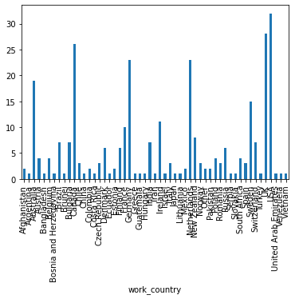

```python
#developing a bar plot to visualize our countries an dtheir importance.
p_data5.groupby('work_country')['age'].nunique().plot(kind='bar')
plt.show()
```

```python
p_data6 = p_data5[p_data5['work_country'].isin(['USA', 'UK', 'Netherlands', 'Germany', 'Canada', 'Australia', 'France', 'Sweden'])]
p_data6.shape
```

```
(53802, 21)
```

We have remained with 53,802 respondents to work with which is a substantial data for the analysis as compared with teh original number of 60,186 respondents.

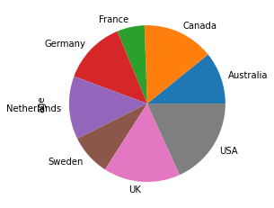

```python
#visualizing the countries that remained.
p_data6.groupby('work_country')['age'].nunique().plot(kind='pie')
plt.show()
```

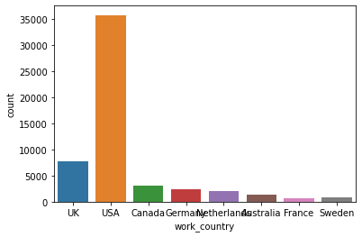

```python
#visualizing the results above using a countplot
sb.countplot(p_data6.work_country)
```

So far the data cleaning procedures for the survey data have been minimal, this is because most of the responses that were obtained from teh survey were controlled so as not to give errors, and there were numeric variables in the data that would make data cleaning procedures necessary.

## b) Summarry statistics.

### Number of survey reponses.

```python
#checking the number of respondets in the survey data by finding the first element in the tuple
print ('The number of survey respondents is: ' + str(s_data.shape[0]))
```

```
The number of survey respondents is: 38
```

### Number of observations in external data

```python
#checking the number of respondets in the survey data by finding the first element in the tuple
print ('The number of observations is: ' + str(p_data.shape[0]))
```

```
The number of observations is: 60186
```

### Demographics and key variables.

We will be checking the summary statistics for our two datasets.

```python
#checking out the summary statistics for our survey data.
s_data.describe()
```

|  | Age_bracket | Gender | Kenyan_citizen | County | Town | Level_of_education | Occupation | Income_level | Social_life | Responsibilities | Hospital | Mental_issues_know | Access_Facilities | Mental_Facilities_Km | Reason |
| --- | --- | --- | --- | --- | --- | --- | --- | --- | --- | --- | --- | --- | --- | --- | --- |
| count | 38 | 38 | 38 | 38 | 38 | 38 | 38 | 38 | 38 | 38 | 38 | 38 | 38 | 38 | 38 |
| unique | 5 | 2 | 2 | 7 | 2 | 5 | 5 | 3 | 3 | 5 | 3 | 3 | 2 | 2 | 5 |
| top | 26-30 | Male | Yes | Nairobi | Town area | Bachelors Degree | Employed in an organization | For my age group, would consider average | Partly social | None | 0-5km | Have an idea | No | No | Learn my mental health status |
| freq | 26 | 22 | 37 | 17 | 25 | 26 | 25 | 18 | 29 | 20 | 30 | 19 | 24 | 24 | 17 |

```python
p_data6.columns
```

```
Index(['employment', 'no_employees', 'type_employer', 'previous_employer',
       'family_history', 'history_mhd', 'current_mhd', 'mhd_condition',
       'mhd_condition2', 'prof_diagnosis', 'mhd_condition3', 'treatment',
       'age', 'gender', 'age_group', 'country', 'work_country',
       'work_position', 'work_remotely', 'question_group', 'mental_pysical'],
      dtype='object')
```

```python
#summmary statistics for the publicly obtained data.
p_data66 = p_data6.drop(['age'], axis = 1)
p_data66.describe()
```

|  | employment | no_employees | type_employer | previous_employer | family_history | history_mhd | current_mhd | mhd_condition | mhd_condition2 | prof_diagnosis | mhd_condition3 | treatment | gender | age_group | country | work_country | work_position | work_remotely | question_group | mental_pysical |
| --- | --- | --- | --- | --- | --- | --- | --- | --- | --- | --- | --- | --- | --- | --- | --- | --- | --- | --- | --- | --- |
| count | 53802 | 53802 | 53802 | 53802 | 53802 | 53802 | 53802 | 53802 | 53802 | 53802 | 53802 | 53802 | 53802 | 53802 | 53802 | 53802 | 53802 | 53802 | 53802 | 53802 |
| unique | 2 | 6 | 2 | 2 | 3 | 3 | 3 | 123 | 84 | 2 | 108 | 2 | 3 | 11 | 18 | 8 | 243 | 3 | 6 | 2 |
| top | False | 26-100 | True | True | Yes | Yes | Yes | None | None | True | None | True | Male | 31-35 | United States of America | USA | Back-end Developer | Sometimes | Speaking openly about a mental health disorder... | No |
| freq | 43554 | 13902 | 40698 | 47712 | 25788 | 28476 | 22638 | 31458 | 42084 | 27846 | 26082 | 32550 | 38682 | 13902 | 35154 | 35742 | 9744 | 28476 | 16653 | 40992 |

```python
#summary statistics for the age column alone
p_data6.describe()
```

|  | age |
| --- | --- |
| count | 53802.000000 |
| mean | 33.102430 |
| std | 6.460654 |
| min | 15.000000 |
| 25% | 28.000000 |
| 50% | 33.000000 |
| 75% | 37.000000 |
| max | 49.000000 |

```python
s_data.columns
```

```
Index(['Age_bracket', 'Gender', 'Kenyan_citizen', 'County', 'Town',
       'Level_of_education', 'Occupation', 'Income_level', 'Social_life',
       'Responsibilities', 'Hospital', 'Mental_issues_know',
       'Access_Facilities', 'Mental_Facilities_Km', 'Reason'],
      dtype='object')
```

```python
gkk = s_data.groupby('County')
gkk.first()
```

| County | Age_bracket | Gender | Kenyan_citizen | Town | Level_of_education | Occupation | Income_level | Social_life | Responsibilities | Hospital | Mental_issues_know | Access_Facilities | Mental_Facilities_Km | Reason |
| --- | --- | --- | --- | --- | --- | --- | --- | --- | --- | --- | --- | --- | --- | --- |
| Kajiado | 26-30 | Female | Yes | Town area | Bachelors Degree | Self-employed | For my age group, would consider average | Partly social | Prefer not to disclose | 0-5km | Have an idea | No | No | Know more about the field |
| Kenya | 35-40 | Male | Yes | Town area | Masters Degree | Employed in an organization | For my age group, above average | Partly social | Primary carer of a child or children (under 18... | 0-5km | Well knowledgeable | Yes | No | Learn my mental health status |
| Kiambu | 26-30 | Male | Yes | Outcasts (5km+ from main town) | Bachelors Degree | Employed in an organization | For my age group, would consider average | Partly social | None | 0-5km | Have an idea | No | No | Learn my mental health status |
| Mombasa | 26-30 | Male | Yes | Town area | Bachelors Degree | Employed in an organization | For my age group, above average | Partly social | None | 0-5km | Well knowledgeable | Yes | Yes | Learn my mental health status |
| Nairobi | 41-45 | Female | Yes | Town area | Bachelors Degree | Self-employed | For my age group, above average | Highly social | Primary carer of a child or children (under 18... | 0-5km | Have an idea | Yes | Yes | Recommend someone close to me to the service /... |
| UAE | 26-30 | Male | No | Town area | Masters Degree | Employed in an organization | For my age group, above average | Partly social | None | 0-5km | Well knowledgeable | Yes | Yes | Learn my mental health status |
| Uasin Gishu | 50+ | Female | Yes | Outcasts (5km+ from main town) | Bachelors Degree | Employed in an organization | For my age group, above average | Partly social | Primary carer of a child or children (under 18... | 6-10km | Well knowledgeable | No | Yes | Seek help |

```python
s_data.columns
```

```
Index(['Age_bracket', 'Gender', 'Kenyan_citizen', 'County', 'Town',
       'Level_of_education', 'Occupation', 'Income_level', 'Social_life',
       'Responsibilities', 'Hospital', 'Mental_issues_know',
       'Access_Facilities', 'Mental_Facilities_Km', 'Reason'],
      dtype='object')
```

```python
pd.crosstab(index = s_data.Age_bracket, columns = s_data.Gender)
```

| Gender Age_bracket | Female | Male |
| --- | --- | --- |
| 18-25 | 0 | 3 |
| 26-30 | 11 | 15 |
| 35-40 | 1 | 1 |
| 41-45 | 1 | 2 |
| 50+ | 3 | 1 |

# 4. Analysis.

## Univariate analysis.

We will be analysing individual variables in the datasets.

### Survey data.

The first question we will ask ourselves is what age bracket does our respondents fall into.

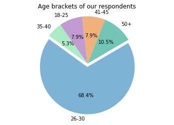

```python
#findning teh age brackets for our respondents usong bars
colors = ['#7FB3D5', '#73C6B6', '#F0B27A', '#C39BD3', '#ABEBC6', '#F4D03F']

s_data['Age_bracket'].value_counts().nlargest(10).plot(kind = "pie", startangle = 144 ,colors = colors,explode = (0.07,0,0,0,0),autopct = '%1.1f%%')

plt.title('Age brackets of our respondents')
plt.axis('equal')
plt.xlabel(None)
plt.ylabel(None)
plt.show()
```

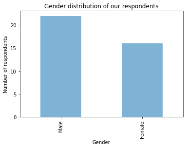

```python
#creating a bar plot to visualize the gender distribution.
s_data['Gender'].value_counts().sort_values(ascending = False).plot(kind = "bar", color = '#7FB3D5')

#naming of our title xlabel and y label of the graph
plt.title('Gender distribution of our respondents')
plt.xlabel('Gender')
plt.ylabel('Number of respondents')
set()
plt.show()
```

From the plot above more than 20 respondents were male and about 15 were female. We will then look at how many respondents had knowledge about mental illnesses.

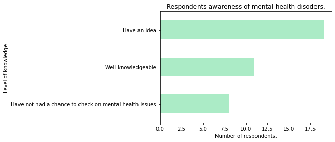

```python
#using the barh kind plot to visualize the number of respondets who are aware of mental helath disoders
s_data.Mental_issues_know.value_counts().sort_values(ascending = True).plot(kind = 'barh', color ='#ABEBC6' )

#setting the labels for our title x and y
plt.title('Respondents awareness of mental health disoders.')
plt.xlabel('Number of respondents.')
plt.ylabel('Level of knowledge.')
set()
plt.show()
```

Majority of the respondents have an idea what mental helath entails, more than 10 respondents are well knowledgeable in the field while a few that is 8 respondents have no idea what is mental health.

### Public data.

We will begin by looking at the country where the respondents work in.

```python
p_data6.columns
```

```
Index(['employment', 'no_employees', 'type_employer', 'previous_employer',
       'family_history', 'history_mhd', 'current_mhd', 'mhd_condition',
       'mhd_condition2', 'prof_diagnosis', 'mhd_condition3', 'treatment',
       'age', 'gender', 'age_group', 'country', 'work_country',
       'work_position', 'work_remotely', 'question_group', 'mental_pysical'],
      dtype='object')
```

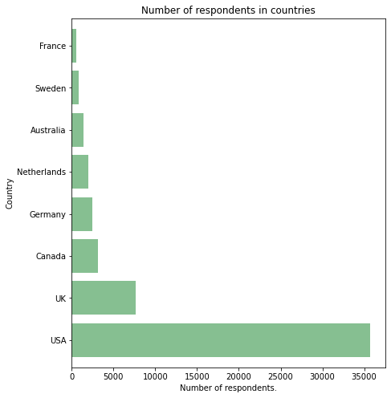

```python
#plotting a bar plot to visualize the countries with the most respondents.

ax = p_data6.work_country.value_counts().plot(kind = 'barh', figsize = (7,8), color = '#86bf91', zorder = 2, width = 0.80)
#naming our labels
plt.title('Number of respondents in countries')
plt.ylabel('Country')
plt.xlabel('Number of respondents.')
plt.show()
```

From the plot above we have seen that the USA tops swith the number of respondnets among the eight countries with the country with the least respondnets being france. We will then move on to analyse the gender of the respondets.

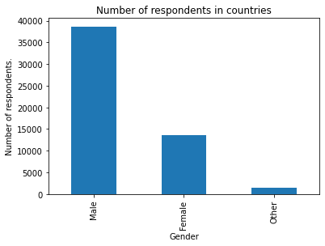

```python
#plotting a bar plot to visualize the countries with the most respondents.
p_data6['gender'].value_counts(ascending = False).plot(kind = "bar" )

#naming our labels
plt.title('Number of respondents in countries')
plt.xlabel('Gender')
plt.ylabel('Number of respondents.')
plt.show()
```

Males have dominated the workplace in our data with more than 35000 respondents, this is followed by females who follow by 15000 respondents and then the trans/other gender closes the charpter with less than 5000 respondnets. We will then analyse if the individuals have had mental a mental disoder in the past.

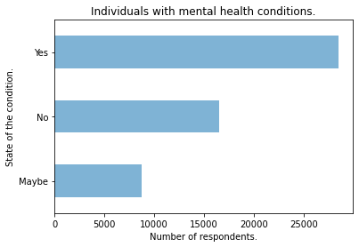

```python
#visualizing the variable using horizontal bar plots
p_data6['history_mhd'].value_counts().sort_values(ascending = True).plot(kind = "barh", color = '#7FB3D5')

#naming our labels
plt.title('Individuals with mental health conditions.')
plt.xlabel('Number of respondents.')
plt.ylabel('State of the condition.')
plt.show()
```

## Bivaraite analysis.

In the bivariate analysis we will be looking to find relationships between variables that could help us answer our research questions.

### Public data.

We will start the analysis of our public data by the analysis of varibles such as work country, gender age_group and the type_of_employer. We will first start with age_group and country.

```python
p_data6.columns
```

```
Index(['employment', 'no_employees', 'type_employer', 'previous_employer',
       'family_history', 'history_mhd', 'current_mhd', 'mhd_condition',
       'mhd_condition2', 'prof_diagnosis', 'mhd_condition3', 'treatment',
       'age', 'gender', 'age_group', 'country', 'work_country',
       'work_position', 'work_remotely', 'question_group', 'mental_pysical'],
      dtype='object')
```

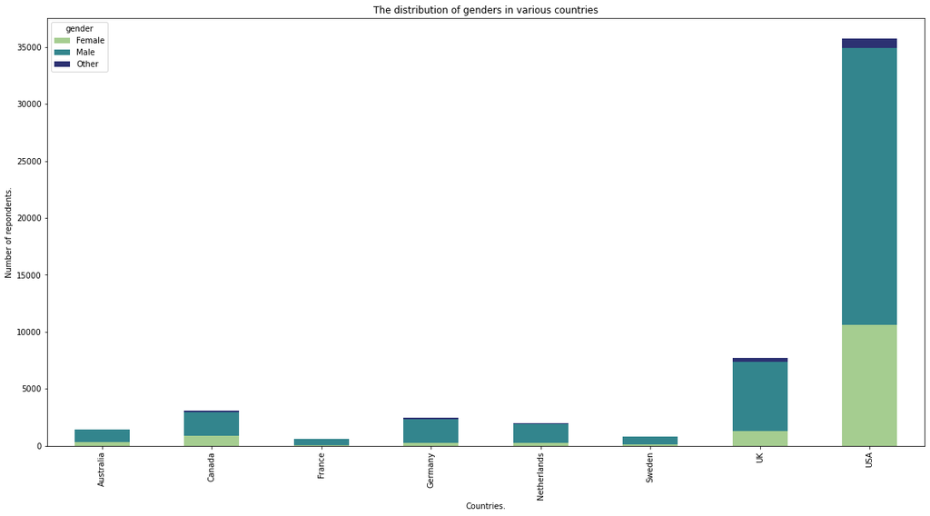

```python
#creating a stacked barplot to represent the information.
p_data61 = pd.crosstab(index = p_data6.work_country, columns = p_data6.gender)
p_data61.plot(kind = 'bar', stacked = True, colormap = 'crest', figsize = (20, 10))
plt.title('The distribution of genders in various countries')
plt.ylabel('Number of repondents.')
plt.xlabel('Countries.')
```

In the above stacked barplot all the three genders are represented we can see that the tech world is ruled by men since they are more than female or trans.

```python
p_data6.columns
```

```
Index(['employment', 'no_employees', 'type_employer', 'previous_employer',
       'family_history', 'history_mhd', 'current_mhd', 'mhd_condition',
       'mhd_condition2', 'prof_diagnosis', 'mhd_condition3', 'treatment',
       'age', 'gender', 'age_group', 'country', 'work_country',
       'work_position', 'work_remotely', 'question_group', 'mental_pysical'],
      dtype='object')
```

We can go on to plot a violin plot that displays the information about the gender and the age.

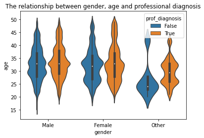

```python
sb.violinplot(x="gender", y="age",hue = 'prof_diagnosis', figsize = (20,10),colormap = 'crest',data=p_data5)
plt.title('The relationship between gender, age and professional diagnosis')
plt.show()
```

### Survey data.

We will start by checking the relationship between the age bracket and the gender.

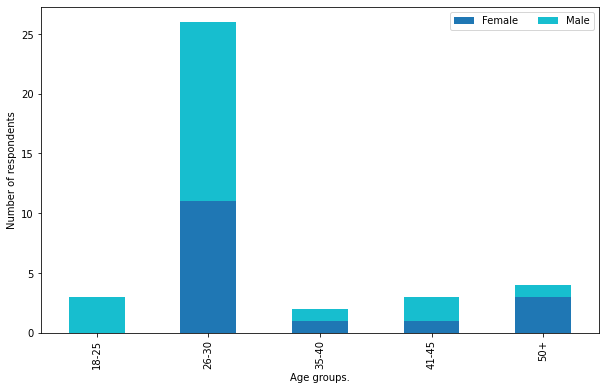

```python
#creating a cross tabulation to display the data data labels on the plot
s_data11 = pd.crosstab(index = s_data.Age_bracket, columns = s_data.Gender)

#creating a 100% stacked table from our cross tabulation
s_data11.plot(kind = 'bar', stacked = True, colormap = 'tab10', figsize = (10, 6))

#naming our labels
plt.xlabel('Age groups.')
plt.ylabel('Number of respondents')

#modifying our legend
plt.legend(loc = 'upper right', ncol = 2)
#adding the proportion to the stacks.
plt.show()
```

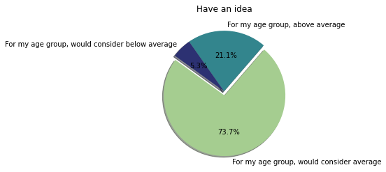

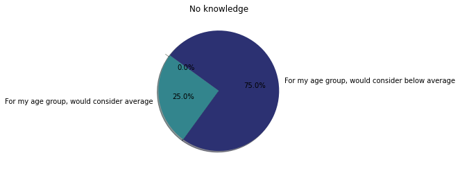

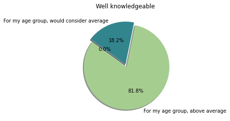

```python
#creating a crosstab for the income level and mental health awareness.
s_data12 = pd.crosstab(index = s_data.Income_level, columns = s_data.Mental_issues_know)

#plotting the pie chart for the column have an idea
x = s_data12['Have an idea'].nlargest(10).plot(kind = "pie", startangle = 144 ,colormap = 'crest',explode = (0.07,0,0),shadow = True, autopct = '%1.1f%%')
plt.ylabel(None)
plt.title('Have an idea')
plt.show()
#plotting the pie chart for the column have not had a chance to check on mental health issues
y =s_data12['Have not had a chance to check on mental health issues'].plot(kind = "pie",shadow = True ,startangle = 144 ,colormap = 'crest',explode = (0.07,0,0),autopct = '%1.1f%%')
plt.ylabel(None)
plt.title('No knowledge')
plt.show()
#plotting a pichart for the column Well knowledgeable
z = s_data12['Well knowledgeable'].nlargest(10).plot(kind = "pie", startangle = 144 ,colormap = 'crest',explode = (0.07,0,0),shadow = True,autopct = '%1.1f%%' )
plt.title('Well knowledgeable')
plt.ylabel(None)
plt.show()
```

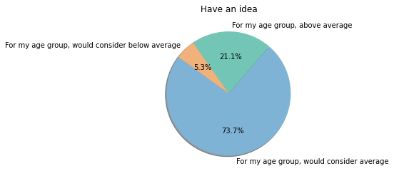

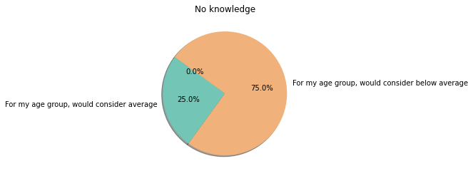

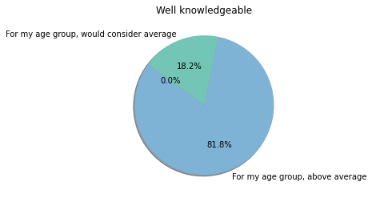

```python
#creating a crosstab for the income level and mental health awareness.
s_data13 = pd.crosstab(index = s_data.Hospital, columns = s_data.Mental_issues_know)
colors = ['#7FB3D5', '#73C6B6', '#F0B27A']
#plotting the pie chart for the column have an idea
x = s_data12['Have an idea'].nlargest(10).plot(kind = "pie", startangle = 144 ,colors = colors,shadow = True, autopct = '%1.1f%%')
plt.ylabel(None)
plt.title('Have an idea')
plt.show()
#plotting the pie chart for the column have not had a chance to check on mental health issues
y =s_data12['Have not had a chance to check on mental health issues'].plot(kind = "pie",shadow = True ,startangle = 144,colors = colors,autopct = '%1.1f%%')
plt.ylabel(None)
plt.title('No knowledge')
plt.show()
#plotting a pichart for the column Well knowledgeable
z = s_data12['Well knowledgeable'].nlargest(10).plot(kind = "pie", startangle = 144 ,colors = colors,shadow = True,autopct = '%1.1f%%' )
plt.title('Well knowledgeable')
plt.ylabel(None)
plt.show()
```

# 5. Conclusion and evaluation.

## a) Key findings.

From the analysis that we have done above here are our key findings.

```python
p_data6.columns
```

```
Index(['employment', 'no_employees', 'type_employer', 'previous_employer',
       'family_history', 'history_mhd', 'current_mhd', 'mhd_condition',
       'mhd_condition2', 'prof_diagnosis', 'mhd_condition3', 'treatment',
       'age', 'gender', 'age_group', 'country', 'work_country',
       'work_position', 'work_remotely', 'question_group', 'mental_pysical'],
      dtype='object')
```

a) for the public data

```
current_mhd  Maybe     No    Yes
gender
Female        2268   3906   7476
Male          9198  15330  14154
Other          420     42   1008
```

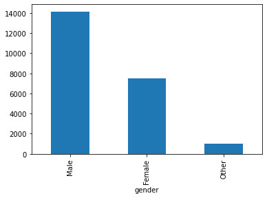

```python
df1 = pd.crosstab(index = p_data6.gender, columns = p_data6.current_mhd)
print(df1)
x = df1['Yes'].nlargest(10).plot(kind = "bar")
```

b) for the survey data.

```python
s_data.columns
```

```
Index(['Age_bracket', 'Gender', 'Kenyan_citizen', 'County', 'Town',
       'Level_of_education', 'Occupation', 'Income_level', 'Social_life',
       'Responsibilities', 'Hospital', 'Mental_issues_know',
       'Access_Facilities', 'Mental_Facilities_Km', 'Reason'],
      dtype='object')
```

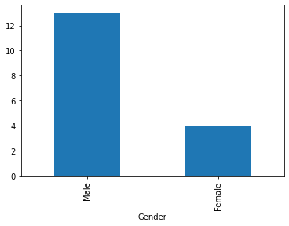

```python
df2 = pd.crosstab(index = s_data.Gender, columns = s_data.Reason)
df2
x = df2['Learn my mental health status'].nlargest(10).plot(kind = "bar")
```

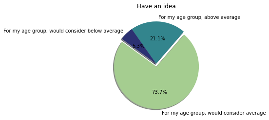

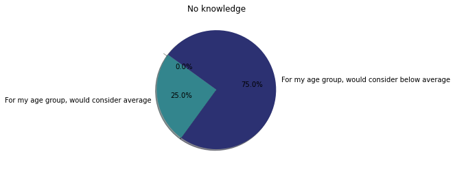

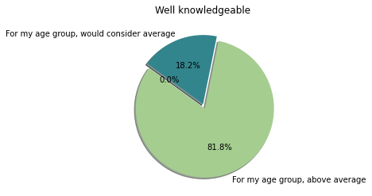

```python
#creating a crosstab for the income level and mental health awareness.
s_data12 = pd.crosstab(index = s_data.Income_level, columns = s_data.Mental_issues_know)

#plotting the pie chart for the column have an idea
x = s_data12['Have an idea'].nlargest(10).plot(kind = "pie", startangle = 144 ,colormap = 'crest',explode = (0.07,0,0),shadow = True, autopct = '%1.1f%%')
plt.ylabel(None)
plt.title('Have an idea')
plt.show()
#plotting the pie chart for the column have not had a chance to check on mental health issues
y =s_data12['Have not had a chance to check on mental health issues'].plot(kind = "pie",shadow = True ,startangle = 144 ,colormap = 'crest',explode = (0.07,0,0),autopct = '%1.1f%%')
plt.ylabel(None)
plt.title('No knowledge')
plt.show()
#plotting a pichart for the column Well knowledgeable
z = s_data12['Well knowledgeable'].nlargest(10).plot(kind = "pie", startangle = 144 ,colormap = 'crest',explode = (0.07,0,0),shadow = True,autopct = '%1.1f%%' )
plt.title('Well knowledgeable')
plt.ylabel(None)
plt.show()
```

## b) Future directions.

In the current time the challenges of accesing credible medical data is a great chaalllenge to analysts, this is due tio the fact that medical data is very sensitive and given the current conditions of cooporations such as facebook being sued for data breach cases the future is going to be tougher. With enough medical data in the low and middle income countries we can use it to study the trajectories of mental health disoders in the world.

## c) Evaluation.

The problem of mental health awarenes and mental helath in the workplace will continue to affect every individual to different proportions, unless the necessary strategies are put in place so as to tackle the problem then we will continue to experience higher suicide rates among individuals.

Employers will need to incraese improve on their way on how they handle mental health challenges in the workplace so that they can create a safe environment for their employees.

## d) Future improvements.

The survey should have a more ambitious sample population i.e., x >5,000 considering Kenya’s population of 52 million with response rate of +-5% of the current study’s rate. To achieve this, the survey should be made available in all social media platforms with the responds encouraged to share amongst family and friends. A USSD survey format should also be used for those with limited internet connections.

In the current time the challenges of accesing credible medical data is a great chaalllenge to analysts, this is due tio the fact that medical data is very sensitive and given the current conditions of cooporations such as facebook being sued for data breach cases the future is going to be tougher. With enough medical data in the low and middle income countries we can use it to study the trajectories of mental health disoders in the world.

# 6. References

- Saloni Dattani, Hannah Ritchie and Max Roser (2021) - "Mental Health". Published online at OurWorldInData.org. Retrieved from: 'https://ourworldindata.org/mental-health' [Online Resource]
  - Matt ritchel (2021) - "Surgeon General Warns of Youth Mental Health Crisis". Published online at nytimes.com. Retrived from https://www.nytimes.com/2021/12/07/science/pandemic-adolescents-depression-anxiety.html. [Online source]
  - 'Suicide' published online at who.int. on 17th June 2021. Retrived from https://www.who.int/news-room/fact-sheets/detail/suicide. [Online source]
  - World health organization: mental disorders, 28th November 2019.
  - MIT news, Massachusetts institute of technology (MIT): Toward a smarter electronic health record, adam zewe, 23rd September 2021.
  - Springer link: 2D MRI image analysis and brain tumor detection using deep learning CNN model hari mohan rai and kalyan Charterjee 36111-36141(2021).
  - WHO: suicide 17th June 2021 --Www.psychiatry.org American psychiatric association: stigma prejudice and discrimination against people with mental illness.
  - Www.statista.com Aron O’Neill: age structure in Kenya.
  - Www.mentalhealth.gov What is mental health? 5th August 2020
  - Www.thriveworks.com Definition of mental health according to the DSM-V
  - Nay Chi Lynn, Zin Mar Kyu "Segmentation and Classification of Skin Cancer Melanoma from Skin Lesion Images” 18th International Conference on Parallel and Distributed Computing, Applications and Technologies (PDCAT), 2017
- Whiteford HA, Degenhardt L, Rehm J, et al. Global burden of disease attributable to mental and substance use disorders: findings from the Global Burden of Disease Study 2010. Lancet 2013;382:1575-1586

# Word count

```python
%%js

 //Run this cell to update your word count.

function wordcount() {
    let wordCount = 0
    let extraCount = 0
    let mainBody = true

    let cells = Jupyter.notebook.get_cells()
    cells.forEach((cell) => {
        if (cell.cell_type == 'markdown') {
            let text = cell.get_text()
            //Stop counting as main body when get to References or Appendices.
            if (text.startsWith('# 6. References') ||
                text.startsWith('### Variable descfription.')) {
                mainBody = false
            }
            if (text.startsWith('## Word Coun4t')) {
                text = ''
            }
            if (text) {
                let words = text.toLowerCase().match(/\b[a-z\d]+\b/g)
                if (words) {
                    let cellCount = words.length
                    if (mainBody) {
                        wordCount += cellCount
                    } else {
                        extraCount += cellCount
                    }
                }
            }
        }

    })
    return [wordCount, extraCount]
}

let wc = wordcount()
element.append(`Main word count: ${wc[0]} (References and appendices word count: ${wc[1]})`)
```